# xwMOOC 자연어 처리 - 텍스트

영화 평점 - 무비렌즈(MovieLens)

## 1. 영화

누구나 관심을 갖는 것이 영화다. 누구나 영화에 대한 추억, 회상, 시원함, 애틋한 감정 등이 있을것이다. 물론 해외 영화지만 가장 좋은 평점을 받은 데이터는 어떤 것인지 살펴보는 것도 큰 의미가 있을 듯하다. 또한, 참고한 해외 블로그가 무비렌즈 데이터를 예제로 하여 다양한 최근 R 기법을 소개하고 있어 더불어 익히는 것도 좋을 듯 하다.

`ggplot2`에 IMDB 영화 데이터셋이 포함되어 있다. 과거에 그렇다는 것이다. `ggplot2` 팩키지 크기가 커져 밖으로 빼서 [ggplot2movies](https://cran.r-project.org/web/packages/ggplot2movies/) 팩키지에서 새로이 제공되고 있으니, 평점 데이터를 가지고 데이터 분석을 시작하는 분들에게 좋은 출발점이 될 듯 하다.

- [ggplot2movies: Movies Data](https://cran.r-project.org/web/packages/ggplot2movies/)

## 2. 영화 데이터 분석

### 2.1. 무비렌즈 데이터

[무비렌즈(movieLens)](https://grouplens.org/datasets/movielens/) 데이터에 대한 내용을 확인하고 나서, [movielens 웹사이트](http://files.grouplens.org/datasets/movielens/)에서 크롤링하여 가져온다.

```r
# 0. 환경설정 --------------------------------
library(tidyverse)
library(skimr)
library(lubridate)
library(stringr)
library(rvest)
library(XML)
library(tidytext)
library(wordcloud)
library(ggthemes)
library(extrafont)
loadfonts()
library(doParallel)

# 1. 데이터 가져오기 -------------------------
## 1.1. 가져올 데이터 설정
url <- "http://files.grouplens.org/datasets/movielens/"
dataset_small <- "ml-latest-small"
dataset_full <- "ml-latest"
data_folder <- "data"
archive_type <- ".zip"

## 1.2. 작업 데이터 지정
dataset <- dataset_small
dataset_zip <- paste0(dataset, archive_type)

## 1.3. 데이터 가져와서 압축풀기
if (!file.exists(file.path(data_folder, dataset_zip))) {
    download.file(paste0(url, dataset_zip), file.path(data_folder, dataset_zip))
}

unzip(file.path(data_folder, dataset_zip), exdir = "data", overwrite = TRUE)

## 1.4. 작업결과 재확인
list.files('data/', recursive=TRUE)
```

### 2.2. 무비렌즈 데이터 전처리

다운로드 받은 압축파일을 풀 경우, “movies”, “ratings”, “links”, “tags” CSV 파일이 풀린다. 이를 각각 불러와서 파일크기를 확인한다.

사용자 평점 데이터, 영화데이터, 태그 데이터, 링크 데이터를 살펴보고 적절한 전처리를 수행한다.

```r
## 1.5. 데이터 크기 확인
dataset_files <- c("movies", "ratings", "links", "tags")
suffix <- ".csv"

for (f in dataset_files) {
    path <- file.path(data_folder, dataset, paste0(f, suffix))
    assign(f, read_csv(path, col_types = cols()))
    print(paste(f, "파일크기:", format(object.size(get(f)), units="Mb")))
}
```

```
[1] "movies 파일크기: 0.9 Mb"
[1] "ratings 파일크기: 1.9 Mb"
[1] "links 파일크기: 0.6 Mb"
[1] "tags 파일크기: 0.1 Mb"
```

```r
# 2. 데이터 전처리 -------------------------------
## 2.1. 사용자 평점 데이터
ratings_df <- ratings %>%
    mutate(timestamp = as_datetime(timestamp))

glimpse(ratings_df)
```

```
Observations: 100,004
Variables: 4
$ userId    <int> 1, 1, 1, 1, 1, 1, 1, 1, 1, 1, 1, 1, 1, 1, 1, 1, 1, 1...
$ movieId   <int> 31, 1029, 1061, 1129, 1172, 1263, 1287, 1293, 1339, ...
$ rating    <dbl> 2.5, 3.0, 3.0, 2.0, 4.0, 2.0, 2.0, 2.0, 3.5, 2.0, 2....
$ timestamp <dttm> 2009-12-14 02:52:24, 2009-12-14 02:52:59, 2009-12-1...
```

```r
skim(ratings_df)
```

```
Skim summary statistics
 n obs: 100004
 n variables: 4

Variable type: integer
      var missing complete      n     mean       sd min  p25 median  p75
1 movieId       0   100004 100004 12548.66 26369.2    1 1028 2406.5 5418
2  userId       0   100004 100004   347.01   195.16   1  182  367    520
     max                                                             hist
1 163949 ▇▁▁▁▁▁▁▁
2    671 ▆▅▆▅▆▆▇▆

Variable type: numeric
     var missing complete      n mean   sd min p25 median p75 max
1 rating       0   100004 100004 3.54 1.06 0.5   3      4   4   5
                                                              hist
1 ▁▁▂▁▆▃▇▆

Variable type: POSIXct
        var missing complete      n        min        max     median
1 timestamp       0   100004 100004 1995-01-09 2016-10-16 2005-03-10
  n_unique
1    78141
```

```r
## 2.2. 영화 데이터
movies_df <- movies %>%
    mutate(title = str_trim(title)) %>%
    extract(title, c("title_tmp", "year"), regex = "^(.*) \\(([0-9 \\-]*)\\)$", remove = FALSE) %>%
    mutate(year = ifelse(str_length(year) > 4, as.integer(str_split(year, "-", simplify = TRUE)[1]), as.integer(year))) %>%
    mutate(title = ifelse(is.na(title_tmp), title, title_tmp)) %>%
    select(-title_tmp)  %>%
    mutate(genres = ifelse(genres == "(no genres listed)", `is.na<-`(genres), genres))

glimpse(movies_df)
```

```
Observations: 9,125
Variables: 4
$ movieId <int> 1, 2, 3, 4, 5, 6, 7, 8, 9, 10, 11, 12, 13, 14, 15, 16,...
$ title   <chr> "Toy Story", "Jumanji", "Grumpier Old Men", "Waiting t...
$ year    <int> 1995, 1995, 1995, 1995, 1995, 1995, 1995, 1995, 1995, ...
$ genres  <chr> "Adventure|Animation|Children|Comedy|Fantasy", "Advent...
```

```r
skim(movies_df)
```

```
Skim summary statistics
 n obs: 9125
 n variables: 4

Variable type: character
     var missing complete    n min max empty n_unique
1 genres      18     9107 9125   3  77     0      901
2  title       0     9125 9125   1 151     0     8893

Variable type: integer
      var missing complete    n     mean       sd  min  p25 median   p75
1 movieId       0     9125 9125 31123.29 40782.63    1 2850   6290 56274
2    year       4     9121 9125  1991.97    19.36 1902 1985   1997  2006
     max                                                             hist
1 164979 ▇▁▁▁▁▁▁▁
2   2016 ▁▁▁▁▂▃▇▇
```

```r
## 2.3. 태그 데이터
tags_df <- tags %>%
    mutate(timestamp = as_datetime(timestamp))

glimpse(tags_df)
```

```
Observations: 1,296
Variables: 4
$ userId    <int> 15, 15, 15, 15, 15, 15, 15, 15, 15, 15, 15, 23, 68, ...
$ movieId   <int> 339, 1955, 7478, 32892, 34162, 35957, 37729, 45950, ...
$ tag       <chr> "sandra 'boring' bullock", "dentist", "Cambodia", "R...
$ timestamp <dttm> 2006-01-29 12:29:30, 2007-10-26 21:44:21, 2007-02-0...
```

```r
skim(tags_df)
```

```
Skim summary statistics
 n obs: 1296
 n variables: 4

Variable type: character
  var missing complete    n min max empty n_unique
1 tag       0     1296 1296   2  55     0      582

Variable type: integer
      var missing complete    n     mean       sd min  p25  median
1 movieId       0     1296 1296 42278.95 44628.35   1 2988 26958.5
2  userId       0     1296 1296   417.03   142.18  15  346   431
       p75    max
1 72268.25 164979
2   547       663
                                                              hist
1 ▇▁▂▂▁▂▁▁
2 ▁▁▂▁▃▃▇▁

Variable type: POSIXct
        var missing complete    n        min        max     median
1 timestamp       0     1296 1296 2006-01-14 2016-10-16 2012-07-21
  n_unique
1     1245
```

```r
## 2.4. 링크 데이터
glimpse(links)
```

```
Observations: 9,125
Variables: 3
$ movieId <int> 1, 2, 3, 4, 5, 6, 7, 8, 9, 10, 11, 12, 13, 14, 15, 16,...
$ imdbId  <chr> "0114709", "0113497", "0113228", "0114885", "0113041",...
$ tmdbId  <int> 862, 8844, 15602, 31357, 11862, 949, 11860, 45325, 909...
```

```r
skim(links)
```

```
Skim summary statistics
 n obs: 9125
 n variables: 3

Variable type: character
     var missing complete    n min max empty n_unique
1 imdbId       0     9125 9125   7   7     0     9125

Variable type: integer
      var missing complete    n     mean       sd min     p25 median
1 movieId       0     9125 9125 31123.29 40782.63   1 2850      6290
2  tmdbId      13     9112 9125 39104.55 62814.52   2 9451.75  15852
      p75    max
1 56274   164979
2 39160.5 416437
                                                              hist
1 ▇▁▁▁▁▁▁▁
2 ▇▁▁▁▁▁▁▁
```

## 3. 탐색적 데이터 분석

csv 파일을 데이터프레임으로 불러오게 되면 이제 데이터를 분석할 준비가 완료되어 있다. 탐색적 데이터 분석을 위해서 데이터를 통해 해결하려는 질문을 뽑아보자.

- 연도별 출하되는 영화는 몇편이나 될까?
- 각 쟝르별로 출하되는 영화편수는 어떨까?
- 각 쟝르를 특정 짓는 태그는 어떤 것이 있을까?
- 사용자 평점에 기초한 시대별 최고 영화는 무엇일까?
- 사용자 평점에 기초한 쟝르별 최고 영화는 무엇일까?

### 3.1. 연도별 출하되는 영화는 몇편이나 될까?

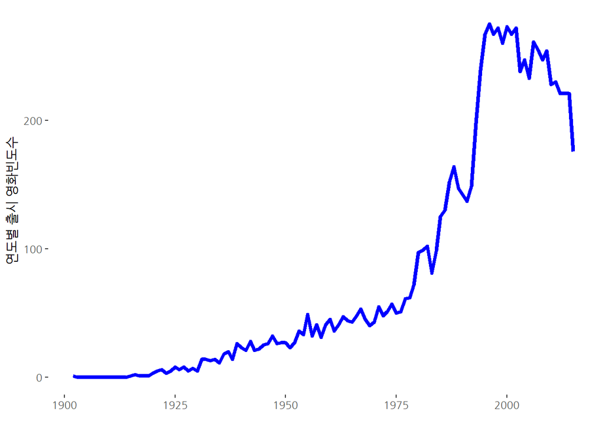

```r
# 3. 탐색적 데이터 분석 --------------------------------------
## 3.1. 연도별 영화 출하 분석 --------------------------------
movies_per_year <- movies_df %>%
    na.omit() %>%
    select(movieId, year) %>%
    group_by(year) %>%
    summarise(count = n())  %>%
    arrange(year)

movies_per_year %>%
    complete(year = full_seq(year, 1), fill = list(count = 0)) %>%
    filter(year <=2015) %>%
    ggplot(aes(x = year, y = count)) +
    geom_line(color="blue", size=1.5) +
    scale_y_continuous(labels=scales::comma) +
    theme_tufte(base_family="NanumGothic") +
    labs(x="", y="연도별 출시 영화빈도수")
```

### 3.2. 각 쟝르별로 출하되는 영화편수는 어떨까?

```r
## 3.1. 연도별 영화 쟝르 출하 분석 --------------------------------
movies_df %>%
    separate_rows(genres, sep = "\\|") %>%
    count(genres) %>%
    arrange(desc(n)) %>%
    mutate(비율 = scales::percent(n/sum(n, na.rm=TRUE)),
             누적비율 = scales::percent(cumsum(n/sum(n, na.rm=TRUE)))) %>%
    select(영화장르 = genres, 쟝르빈도수=n, 쟝르비율=비율, 누적비율) %>%
    DT::datatable() %>%
    DT::formatRound("쟝르빈도수", interval=3, digits=0)

movies_df %>%
    separate_rows(genres, sep = "\\|") %>%
    na.omit() %>%
    mutate(genres = as.factor(genres)) %>%
    group_by(year, genres) %>%
    summarise(number = n()) %>%
    complete(year = full_seq(year, 1), genres, fill = list(number = 0)) %>%
    filter(genres %in% c("Drama", "Comedy", "Thriller", "Romance", "Action", "Horror")) %>%
    filter(year >= 1900 & year <= 2015) %>%
    ggplot(aes(x = year, y = number)) +
    geom_line(aes(color=genres)) +
    scale_fill_brewer(palette = "Paired") +
    theme_tufte(base_family="NanumGothic") +
    labs(x="", y="연도별 출시 영화빈도수", color="쟝르") +
    theme(legend.position = "top")
```

[output not shown]

### 3.3. 사용자 평점에 기초한 시대별 최고 영화는 무엇일까?

```r
## 3.4. 사용자 평점에 기초한 시대별 최고 영화
# https://districtdatalabs.silvrback.com/computing-a-bayesian-estimate-of-star-rating-means

avg_rating <- ratings_df %>%
    inner_join(movies_df, by = "movieId") %>%
    na.omit() %>%
    select(movieId, title, rating, year) %>%
    group_by(movieId, title, year) %>%
    summarise(count = n(), mean = mean(rating), min = min(rating), max = max(rating)) %>%
    ungroup() %>%
    arrange(desc(mean))

weighted_rating <- function(R, v, m, C) {
    return (v/(v+m))*R + (m/(v+m))*C
}

# R = average for the movie (mean) = (Rating)
# v = number of votes for the movie = (votes)
# m = minimum votes required to be listed in the Top 250
# C = the mean vote across the whole report
avg_rating <- avg_rating %>%
    mutate(wr = weighted_rating(mean, count, 500, mean(mean))) %>%
    arrange(desc(wr))

avg_rating


avg_rating %>%
    mutate(decade = year  %/% 10 * 10) %>%
    arrange(year, desc(wr)) %>%
    group_by(decade) %>%
    summarise(title = first(title), wr = first(wr), mean = first(mean), count = first(count)) %>%
    DT::datatable() %>%
    DT::formatRound("count", digits = 0, interval = 3)
```

[output not shown]

### 3.4. 사용자 평점에 기초한 쟝르별 최고 영화는 무엇일까?

```r
## 3.5. 사용자 평점에 기초한 쟝르별 최고 영화

genres_rating <- movies_df %>%
    na.omit() %>%
    select(movieId, year, genres) %>%
    inner_join(ratings_df, by = "movieId") %>%
    select(-timestamp, -userId) %>%
    mutate(decade = year  %/% 10 * 10) %>%
    separate_rows(genres, sep = "\\|") %>%
    group_by(year, genres) %>%
    summarise(count = n(), avg_rating = mean(rating)) %>%
    ungroup() %>%
    mutate(wr = weighted_rating(mean, count, 500, mean(mean))) %>%
    arrange(year)

genres_rating %>%
    filter(genres %in% c("Action", "Romance", "Sci-Fi", "Western")) %>%
    ggplot(aes(x = year, y = wr)) +
    geom_line(aes(group=genres, color=genres)) +
    geom_smooth(aes(group=genres, color=genres)) +
    facet_wrap(~genres)
```

[output not shown]

## 3.5. 각 쟝르를 특정 짓는 태그는 어떤 것이 있을까?

```r
## 3.3. 각 쟝르별 태그 --------------------------------
genres_tags <- movies_df %>%
    na.omit() %>%
    select(movieId, year, genres) %>%
    separate_rows(genres, sep = "\\|") %>%
    inner_join(tags_df, by = "movieId") %>%
    select(genres, tag) %>%
    group_by(genres) %>%
    nest()
```

### 액션(Action)

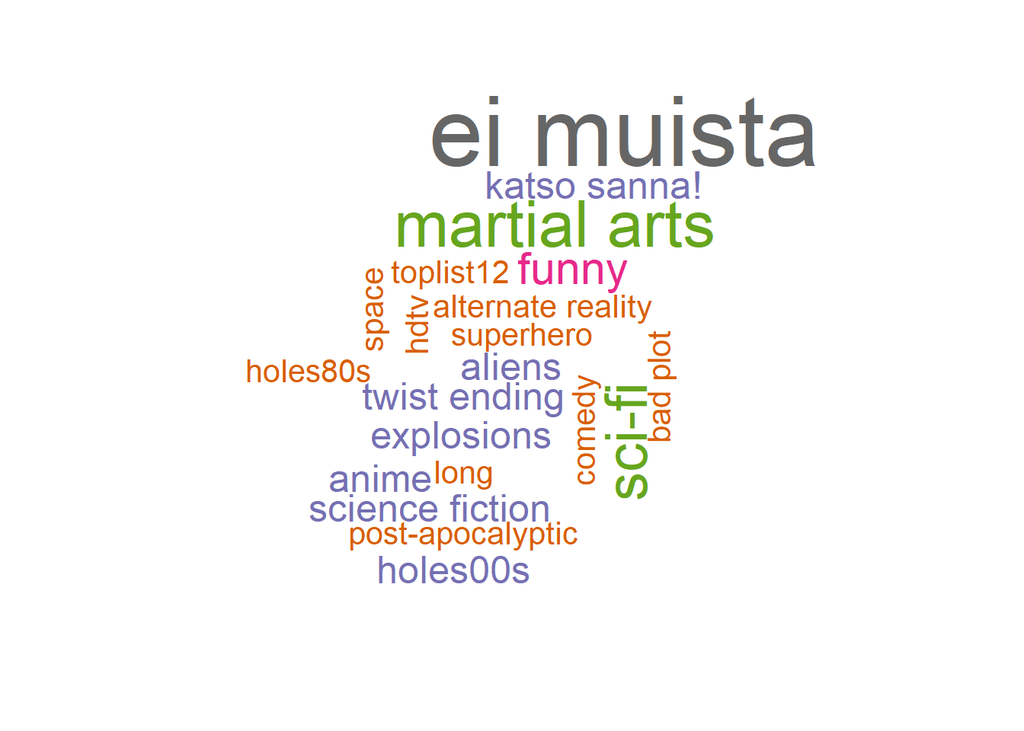

```r
genre<-"Action"
genre_words <- genres_tags %>%
    filter(genres == genre) %>%
    unnest() %>%
    mutate(tag = str_to_lower(tag, "en")) %>%
    anti_join(tibble(tag=c(tolower(genre)))) %>%
    count(tag)

wordcloud(genre_words$tag, genre_words$n, max.words = 50, colors=brewer.pal(8, "Dark2"))
```

### 코메디(Comedy)

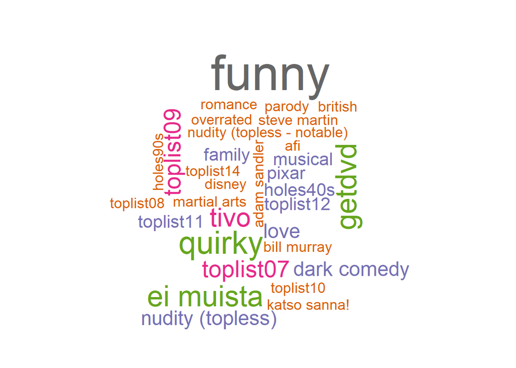

```r
# plot wordcloud per genre
genre<-"Comedy"
genre_words <- genres_tags %>%
  filter(genres == genre) %>%
  unnest() %>%
  mutate(tag = str_to_lower(tag, "en")) %>%
  anti_join(tibble(tag=c(tolower(genre)))) %>%
  count(tag)

  wordcloud(genre_words$tag, genre_words$n, max.words = 50, colors=brewer.pal(8, "Dark2"))
```

### 드라마(Drama)

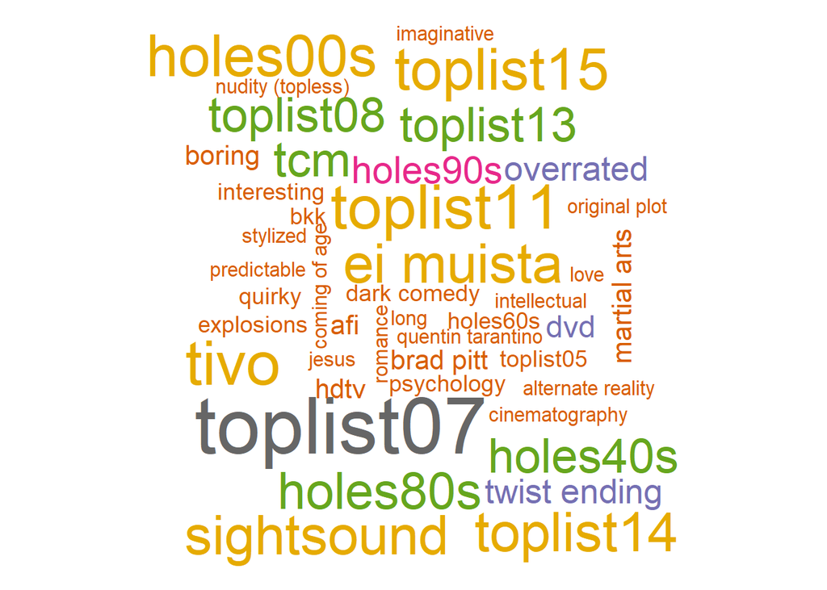

```r
# plot wordcloud per genre
genre<-"Drama"
genre_words <- genres_tags %>%
  filter(genres == genre) %>%
  unnest() %>%
  mutate(tag = str_to_lower(tag, "en")) %>%
  anti_join(tibble(tag=c(tolower(genre)))) %>%
  count(tag)

  wordcloud(genre_words$tag, genre_words$n, max.words = 50, colors=brewer.pal(8, "Dark2"))
```

### 스릴러물(Thriller)

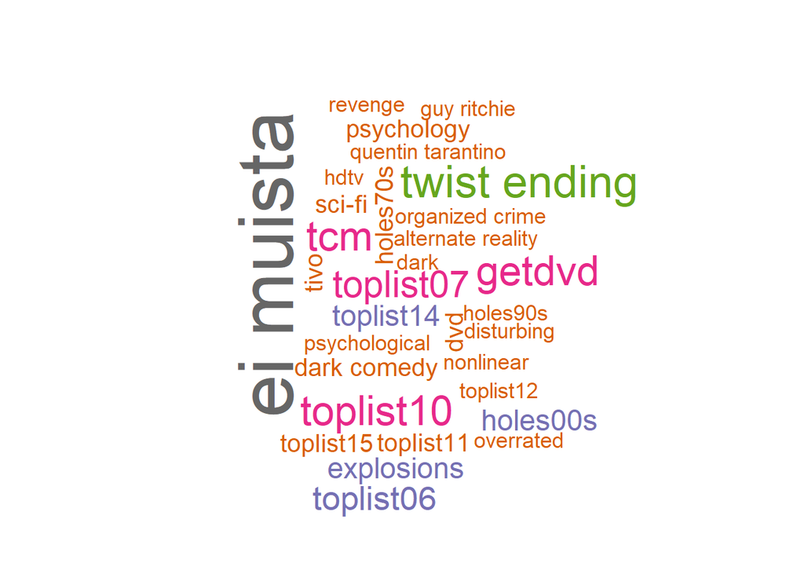

```r
# plot wordcloud per genre
genre<-"Thriller"
genre_words <- genres_tags %>%
  filter(genres == genre) %>%
  unnest() %>%
  mutate(tag = str_to_lower(tag, "en")) %>%
  anti_join(tibble(tag=c(tolower(genre)))) %>%
  count(tag)

  wordcloud(genre_words$tag, genre_words$n, max.words = 50, colors=brewer.pal(8, "Dark2"))
```

### 공포(Horror)

[figure not shown]

```r
# plot wordcloud per genre
genre<-"Horror"
genre_words <- genres_tags %>%
  filter(genres == genre) %>%
  unnest() %>%
  mutate(tag = str_to_lower(tag, "en")) %>%
  anti_join(tibble(tag=c(tolower(genre)))) %>%
  count(tag)

  wordcloud(genre_words$tag, genre_words$n, max.words = 50, colors=brewer.pal(8, "Dark2"))
```

### 아동(Children)

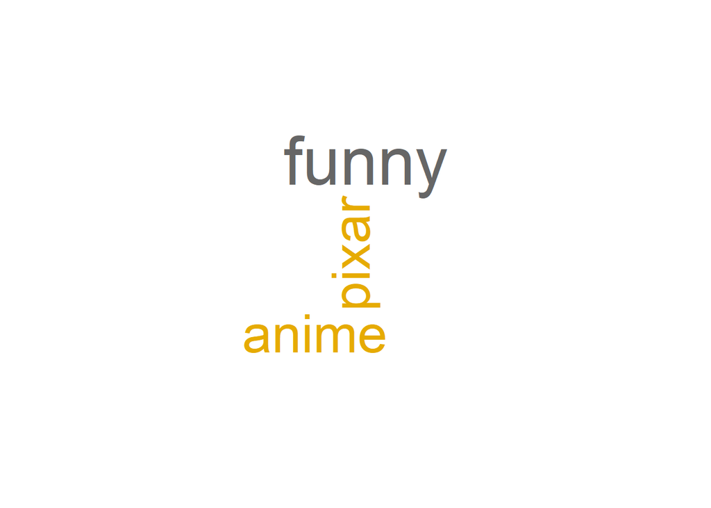

```r
# plot wordcloud per genre
genre<-"Children"
genre_words <- genres_tags %>%
  filter(genres == genre) %>%
  unnest() %>%
  mutate(tag = str_to_lower(tag, "en")) %>%
  anti_join(tibble(tag=c(tolower(genre), "animation"))) %>%
  count(tag)

  wordcloud(genre_words$tag, genre_words$n, max.words = 50, colors=brewer.pal(8, "Dark2"))
```

### 범죄(Crime)

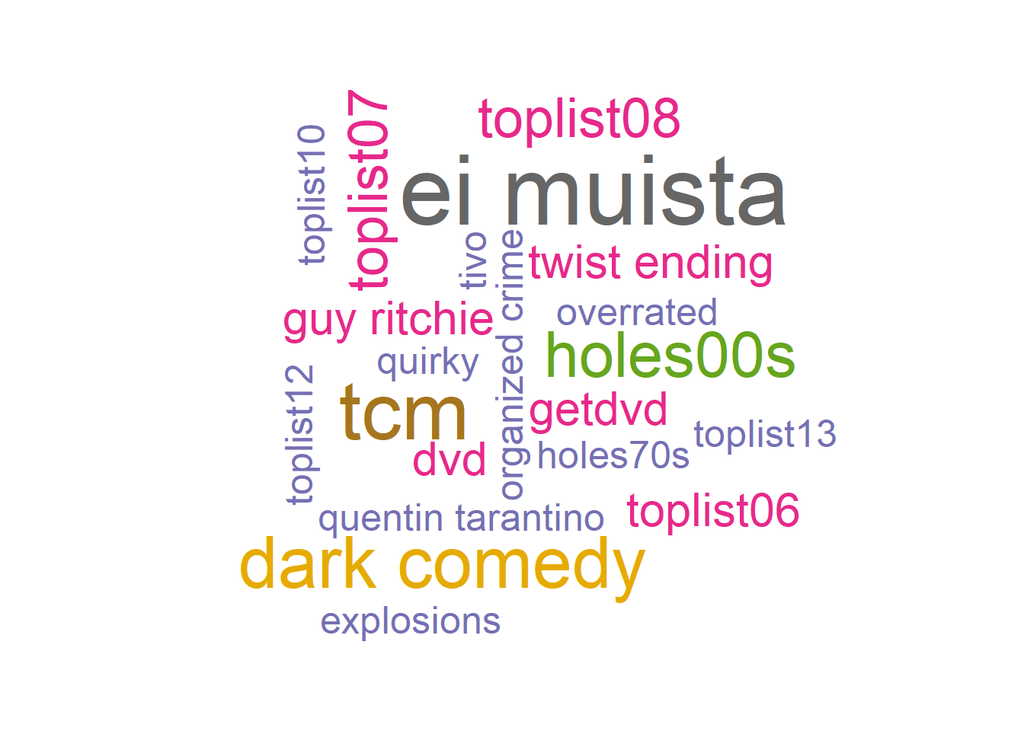

```r
# plot wordcloud per genre
genre<-"Crime"
genre_words <- genres_tags %>%
  filter(genres == genre) %>%
  unnest() %>%
  mutate(tag = str_to_lower(tag, "en")) %>%
  anti_join(tibble(tag=c(tolower(genre)))) %>%
  count(tag)

  wordcloud(genre_words$tag, genre_words$n, max.words = 50, colors=brewer.pal(8, "Dark2"))
```

### 로맨스(Romance)

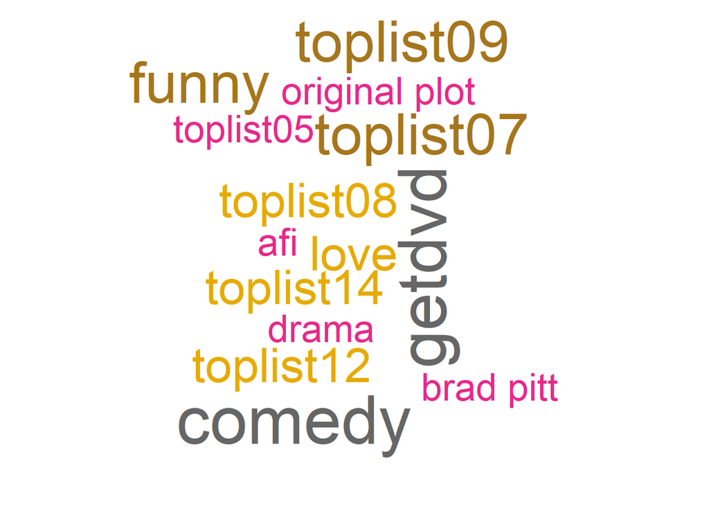

```r
# plot wordcloud per genre
genre<-"Romance"
genre_words <- genres_tags %>%
  filter(genres == genre) %>%
  unnest() %>%
  mutate(tag = str_to_lower(tag, "en")) %>%
  anti_join(tibble(tag=c(tolower(genre)))) %>%
  count(tag)

  wordcloud(genre_words$tag, genre_words$n, max.words = 50, colors=brewer.pal(8, "Dark2"))
```